Description

Problem statement:

People all throughout Los Angeles are concerned about recent reports of crimes in numerous locations. The mayor of Los Angeles has established a new Criminal Investigation Division to study how and why crime is on the rise, as well as the elements that contribute to it, so that officials may take the necessary steps to keep the city's residents safe.

Objective:

As a member of the Analytics Division, you are aware that there are numerous questions that must be answered utilizing CID data. However, this data is not organized and is simply exported as flat files that can only be viewed if there are problems! You must create a pipeline to organize and manage this data using a SQL database to make it much easier to answer inquiries in the future. Then, using the data, react to the questions and write a detailed report for the authorities to utilize in taking action against crimes in Los Angeles.

I am creating the visualisation, using the data from the SQL results.

Importing the necessary packages

```python
# import libraries for data manipulation
import numpy as np
import pandas as pd

# import libraries for data visualization
import matplotlib.pyplot as plt
import seaborn as sns
# to restrict the float value to 3 decimal places
pd.set_option('display.float_format', lambda x: '%.3f' % x)
```

Reading datasets by using read_csv from pandas package

The Most frequent crime committed each week.

```python
q1 = pd.read_csv('C:/Users/Marie/Downloads/q1.csv')
# display the first 5 rows of the dataset
q1.head()
```

|  | WEEK_NUMBER | CRIME_TYPE |
| --- | --- | --- |
| 0 | 1 | BURGLARY FROM VEHICLE |
| 1 | 2 | BURGLARY FROM VEHICLE |
| 2 | 3 | BATTERY - SIMPLE ASSAULT |
| 3 | 4 | BURGLARY FROM VEHICLE |

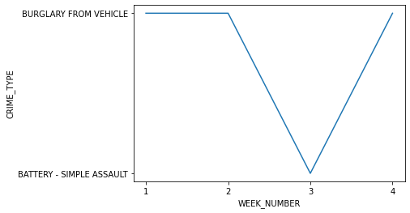

```python
sns.lineplot(x="WEEK_NUMBER", y="CRIME_TYPE", data = q1,)
plt.xticks([1,2,3,4])
plt.show()
```

Observations: The highest crime committed each week are :

- BURGLARY FROM VEHICLE for week 1,2 and 4;
- BATTERY - SIMPLE ASSAULT for week 3;

Comparison of population density, precinct area, officer’s count with crime rate

```python
q2 =  pd.read_csv('C:/Users/Marie/Downloads/q2.csv')
q2.head()
```

|  | PRECINCT_CODE | CASES_REPORTED | TOTAL_AREAS | TOTAL_POPULATION | TOTAL_OFFICERS |
| --- | --- | --- | --- | --- | --- |
| 0 | 1 | 32 | 1 | 616200 | 7 |
| 1 | 2 | 29 | 3 | 1136862 | 9 |
| 2 | 3 | 44 | 2 | 1513542 | 11 |
| 3 | 4 | 37 | 1 | 1980500 | 10 |
| 4 | 5 | 37 | 2 | 713766 | 6 |

```
Observation: The crime depend on the Area name and precinct code not on population density,officer's count.
```

Points of the day the crime rate is at its peak

```python
q3=  pd.read_csv('C:/Users/Marie/Downloads/q3.csv')
q3.head()
```

|  | POINTS_OF_THE_DAY_THE_CRIME_RATE_IS_AT_ITS_PEAK | CRIME_TYPE |
| --- | --- | --- |
| 0 | EVENING | BURGLARY FROM VEHICLE |
| 1 | EVENING | BURGLARY FROM VEHICLE |
| 2 | MORNING | BATTERY - SIMPLE ASSAULT |
| 3 | NIGHT | BURGLARY FROM VEHICLE |

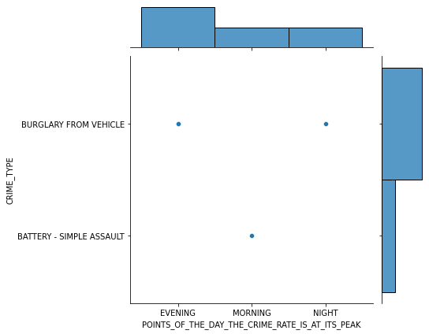

```python
sns.jointplot(x = "POINTS_OF_THE_DAY_THE_CRIME_RATE_IS_AT_ITS_PEAK", y = "CRIME_TYPE", data = q3,)
plt.xticks(rotation=80)
plt.show()
```

Observation is that points of the day the crime rate is at its peak are Night and Evening for BURGLARY FROM VEHICLE, Morning for BATTERY - SIMPLE ASSAULT.

Point in the day more crimes occur in a different locality

```python
q4=  pd.read_csv('C:/Users/Marie/Downloads/q4.csv')
q4.head()
```

|  | AREA_NAME | POINT_IN_THE_DAY_MORE_CRIMES_OCCUR_IN_A_DIFFERENT_LOCALITY |
| --- | --- | --- |
| 0 | 77th Street | NIGHT |
| 1 | Harbor | AFTERNOON |
| 2 | Hollenbeck | MIDNIGHT |
| 3 | Hollywood | AFTERNOON |
| 4 | Newton | AFTERNOON |

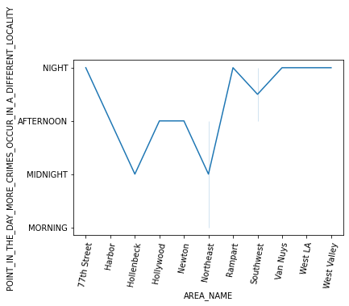

```python
sns.lineplot(x='AREA_NAME', y='POINT_IN_THE_DAY_MORE_CRIMES_OCCUR_IN_A_DIFFERENT_LOCALITY', data = q4,)
plt.xticks(rotation=80)
plt.show()
```

Observation is that Point in the day more crimes occur in a different locality are Night for 77th Street, AFTERNOON for Harbor, MIDNIGHT for Hollenbeck, AFTERNOON for Hollywood and AFTERNOON for Newton.

Age group of people is more likely to fall victim to crimes at certain points in the day

```python
q5=  pd.read_csv('C:/Users/Marie/Downloads/q5.csv')
q5.head()
```

|  | AGE_GROUP | DAY_PARTS |
| --- | --- | --- |
| 0 | Adults | AFTERNOON |
| 1 | Adults | MORNING |
| 2 | Adults | EVENING |
| 3 | Adults | MIDNIGHT |
| 4 | Adults | NIGHT |

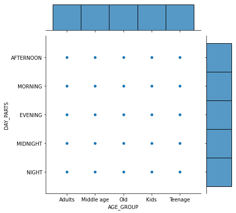

```python
sns.jointplot(x='AGE_GROUP', y='DAY_PARTS', data = q5,)
plt.xticks(rotation=80)
plt.show()
```

The status of reported crimes

```python
q6=  pd.read_csv('C:/Users/Marie/Downloads/q6.csv')
q6.head()
```

|  | CASE_STATUS_CODE | REPORTED_CRIMES |
| --- | --- | --- |
| 0 | IC | 1186 |
| 1 | AA | 94 |
| 2 | AO | 38 |

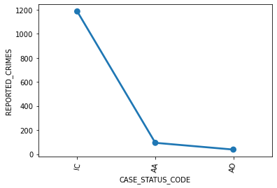

```python
sns.pointplot(x = "CASE_STATUS_CODE", y = "REPORTED_CRIMES", data = q6,)
plt.xticks(rotation=80)
plt.show()
```

Observation is that The status of reported crimes are:

-IC = 1186, -AA = 94, -AO = 38

Distribution of area and CCTV count in relation to crime rate

```python
q7 = pd.read_csv('C:/Users/Marie/Downloads/q7.csv')
q7.head()
```

|  | AREA_NAME | CCTV_COUNT | CRIME_RATE |
| --- | --- | --- | --- |
| 0 | Rampart | 165 | 233 |
| 1 | Hollenbeck | 170 | 189 |
| 2 | Van Nuys | 250 | 158 |
| 3 | West LA | 244 | 156 |
| 4 | West Valley | 268 | 156 |

Distribution to see whether CCTV footage is available or not at the crime scene for each area

```python
q8=  pd.read_csv('C:/Users/Marie/Downloads/q8.csv')
q8.head()
```

|  | AREA_NAME | THE_CCTV_AT_THE_CRIME_SCENE | FOOTAGE | NO FOOTAGE |
| --- | --- | --- | --- | --- |
| 0 | Hollenbeck | 189 | 0 | 0.000 |
| 1 | Harbor | 71 | 0 | 0.000 |
| 2 | Newton | 74 | 0 | 0.000 |
| 3 | Van Nuys | 158 | 0 | 0.000 |
| 4 | West LA | 156 | 0 | 0.000 |

Observation: there is not CCTV footage available at the crime scene for each area. Footage is 0 and no Footage is 0.00

Crimes committed by relation of victim than strangers

```python
q9 = pd.read_csv('C:/Users/Marie/Downloads/q9.csv')
q9.head()
```

|  | CRIME_TYPE | COUNT_OF_CRIME_WHEN_THE_OFFENDER_IS_RELATED_TO_THE_VICTIM |
| --- | --- | --- |
| 0 | BURGLARY FROM VEHICLE | 8 |
| 1 | BATTERY - SIMPLE ASSAULT | 7 |
| 2 | THEFT-GRAND ($950.01 & OVER)EX | 5 |
| 3 | THEFT PLAIN - PETTY ($950 & UN | 4 |
| 4 | SHOPLIFTING - PETTY THEFT ($95 | 4 |

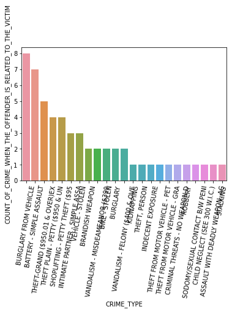

```python
sns.barplot(x = "CRIME_TYPE", y = "COUNT_OF_CRIME_WHEN_THE_OFFENDER_IS_RELATED_TO_THE_VICTIM", data = q9,)
plt.xticks(rotation=80)
plt.show()
```

Observation is that Crimes committed by relation of victim are 8 for BURGLARY FROM VEHICLE, 7 for BATTERY - SIMPLE ASSAULT, 5 for THEFT-GRAND ( 950.01 & OVER)EX, 4 for THEFT PLAIN - PETTY ( 950 & UN and 4 SHOPLIFTING - PETTY THEFT ($95.

The methods used by the public to report a crime

```python
q10 = pd.read_csv('C:/Users/Marie/Downloads/q10.csv')
q10.head()
```

|  | COMPLAINT_TYPE | COUNT_OF_CRIME |
| --- | --- | --- |
| 0 | Phone | 810 |
| 1 | In-Person | 446 |
| 2 | Email | 62 |

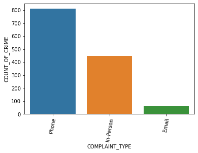

```python
sns.barplot(x = "COMPLAINT_TYPE", y = "COUNT_OF_CRIME", data = q10,)
plt.xticks(rotation=80)
plt.show()
```

Observation is that the methods used by the public to report a crime are Phone, In-Person and Email.

RECOMENDATIOS:

- The City needs to focus more on different locality especially where the crime rate is High;
- Focus on day parts where the points of the day the crime rate is at its peak;
- The City need to investigate CCTV;